# Lab 5: Decision Tress

Juliana Vinluan

2025-03-29

## Background

There is a discrepancy between “not survived” and “not alive” patients. “Not survived” refers to patients who did not survive beyond the study’s specified time frame, whereas “not alive” includes all deceased patients, regardless of the time frame. The distinction is important for modeling survivability rates.

During preprocessing, the authors handled missing data, removed irrelevant features, and converted categorical variables into numerical form. They also normalized continuous data and ensured class balance where needed.

The authors used information gain and statistical tests to evaluate the predictive power of different attributes. Features with higher information gain were considered more influential in predicting survivability.

Best-performing learning algorithm:

The C4.5 decision tree algorithm outperformed other models, such as Naïve Bayes and backpropagation neural networks, in terms of accuracy and interpretability.

Yes, the dataset contained missing values. The authors handled this by either imputing missing values or excluding incomplete records when necessary.

##### First, I will import the data set and load a library package to use later in this report.

```r
# Import data set
cardata <- read.table("car.data", header = FALSE, sep = ",", stringsAsFactors = TRUE)
healthydata <- read.csv("NPHA-doctor-visits.csv", header = TRUE)

# Include library
library(rpart) # Decision tree algorithm
library(rpart.plot) # Decision tree visualization
library(caret) # Classification and regression training
library(ggplot2)  # Visualization
library(dplyr)    # Data manipulation
# Assign column names
colnames(cardata) <- c("buying", "maint", "doors", "persons", "lug_boot", "safety", "acceptability")
colnames(healthydata) <- c("visits", "age", "phyiscal_health", "mental_health", "dental_health", "employment", "stress_prevents_sleeping", "medication_prevents_sleeping", "pain_prevents_sleeping", "bathroom_prevents_sleeping", "unknown_prevents_sleeping", "trouble_sleeping", "prescription_sleep_meds", "race", "gender")
```

## Data Preprocessing

```r
head(cardata)   # View the first few rows
```

```
##   buying maint doors persons lug_boot safety acceptability
## 1  vhigh vhigh     2       2    small    low         unacc
## 2  vhigh vhigh     2       2    small    med         unacc
## 3  vhigh vhigh     2       2    small   high         unacc
## 4  vhigh vhigh     2       2      med    low         unacc
## 5  vhigh vhigh     2       2      med    med         unacc
## 6  vhigh vhigh     2       2      med   high         unacc
```

```r
str(cardata)    # Check the structure (columns, types)
```

```
## 'data.frame':    1728 obs. of  7 variables:
##  $ buying       : Factor w/ 4 levels "high","low","med",..: 4 4 4 4 4 4 4 4 4 4 ...
##  $ maint        : Factor w/ 4 levels "high","low","med",..: 4 4 4 4 4 4 4 4 4 4 ...
##  $ doors        : Factor w/ 4 levels "2","3","4","5more": 1 1 1 1 1 1 1 1 1 1 ...
##  $ persons      : Factor w/ 3 levels "2","4","more": 1 1 1 1 1 1 1 1 1 2 ...
##  $ lug_boot     : Factor w/ 3 levels "big","med","small": 3 3 3 2 2 2 1 1 1 3 ...
##  $ safety       : Factor w/ 3 levels "high","low","med": 2 3 1 2 3 1 2 3 1 2 ...
##  $ acceptability: Factor w/ 4 levels "acc","good","unacc",..: 3 3 3 3 3 3 3 3 3 3 ...
```

```r
dim(cardata)    # Check dimensions (rows, columns)
```

```
## [1] 1728    7
```

```r
# Check for missing values
colSums(is.na(cardata))
```

```
##        buying         maint         doors       persons      lug_boot
##             0             0             0             0             0
##        safety acceptability
##             0             0
```

```r
# Convert categorical variables to factors
cardata[] <- lapply(cardata, as.factor)

# Split into training and test sets
set.seed(123)
trainIndex <- caret::createDataPartition(cardata$acceptability, p = 0.7, list = FALSE)
trainSet <- cardata[trainIndex, ]
testSet <- cardata[-trainIndex, ]
```

## Build Decision Tree

```r
tree_model <- rpart(acceptability ~ ., data = trainSet, method = "class",
                    parms = list(split = "information"))
```

## Visualize Decision Tree

```r
rpart.plot(tree_model)
```

[output not shown]

## Compute Classification Error *before pruning*

```r
pred_train <- factor(predict(tree_model, trainSet, type = "class"), levels = levels(trainSet$acceptability))
pred_test <- factor(predict(tree_model, testSet, type = "class"), levels = levels(trainSet$acceptability))

train_error <- mean(pred_train != trainSet$acceptability)
test_error <- mean(pred_test != testSet$acceptability)

cat("Training Error:", train_error, "\n")
```

```
## Training Error: 0.05202312
```

```r
cat("Test Error:", test_error, "\n")
```

```
## Test Error: 0.06576402
```

## Prune the Tree

```r
printcp(tree_model) # Display complexity parameter table
```

```
##
## Classification tree:
## rpart(formula = acceptability ~ ., data = trainSet, method = "class",
##     parms = list(split = "information"))
##
## Variables actually used in tree construction:
## [1] buying   lug_boot maint    persons  safety
##
## Root node error: 364/1211 = 0.30058
##
## n= 1211
##
##          CP nsplit rel error  xerror     xstd
## 1  0.140110      0   1.00000 1.00000 0.043835
## 2  0.094780      2   0.71978 0.71978 0.039365
## 3  0.054945      4   0.53022 0.54121 0.035284
## 4  0.038462      5   0.47527 0.52473 0.034845
## 5  0.035714      8   0.35989 0.43132 0.032114
## 6  0.030220      9   0.32418 0.37088 0.030088
## 7  0.027473     10   0.29396 0.35165 0.029393
## 8  0.017857     12   0.23901 0.29396 0.027133
## 9  0.015110     14   0.20330 0.25549 0.025456
## 10 0.010000     16   0.17308 0.21978 0.023747
```

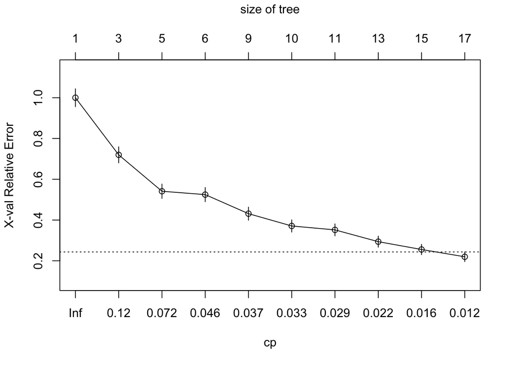

```r
plotcp(tree_model)  # Visualize cp graph
```

```r
# Choose optimal cp value (e.g., lowest cross-validation error)
best_cp <- tree_model$cptable[which.min(tree_model$cptable[, "xerror"]), "CP"] #After finding the index of the minimum xerror, this line extracts the corresponding CP value.
pruned_tree <- prune(tree_model, cp = best_cp) # Prune the tree using the best CP value
```

## Visualize/Compare Original Tree and Pruned Tree

```r
rpart.plot(tree_model)
```

[output not shown]

```r
rpart.plot(pruned_tree)
```

[output not shown]

## Compute Classification Error *after pruning*

```r
pred_train_pruned <- factor(predict(pruned_tree, trainSet, type = "class"), levels = levels(trainSet$acceptability))
pred_test_pruned <- factor(predict(pruned_tree, testSet, type = "class"), levels = levels(trainSet$acceptability))

train_error_pruned <- mean(pred_train_pruned != trainSet$acceptability)
test_error_pruned <- mean(pred_test_pruned != testSet$acceptability)

cat("Pruned Training Error:", train_error_pruned, "\n")
```

```
## Pruned Training Error: 0.05202312
```

```r
cat("Pruned Test Error:", test_error_pruned, "\n")
```

```
## Pruned Test Error: 0.06576402
```

## Repeat with Gini Index

```r
tree_model_gini <- rpart(acceptability ~ ., data = trainSet, method = "class",
                    parms = list(split = "gini"))
```

## Visualize Decision Tree (Gini)

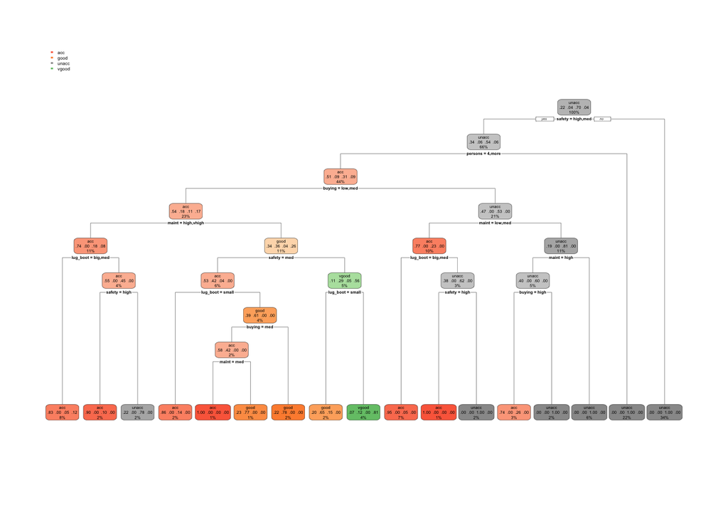

```r
rpart.plot(tree_model_gini)
```

## Compute Classification Error (Gini)

```r
pred_train_gini <- predict(tree_model_gini, trainSet, type = "class")
pred_test_gini <- predict(tree_model_gini, testSet, type = "class")

train_error_gini <- mean(pred_train_gini != trainSet$acceptability)
test_error_gini <- mean(pred_test_gini != testSet$acceptability)

cat("Training Error (Gini):", train_error_gini, "\n")
```

```
## Training Error (Gini): 0.05202312
```

```r
cat("Test Error (Gini):", test_error_gini, "\n")
```

```
## Test Error (Gini): 0.06576402
```

## Prune the Tree (Gini)

```r
printcp(tree_model_gini) # Display complexity parameter table
```

```
##
## Classification tree:
## rpart(formula = acceptability ~ ., data = trainSet, method = "class",
##     parms = list(split = "gini"))
##
## Variables actually used in tree construction:
## [1] buying   lug_boot maint    persons  safety
##
## Root node error: 364/1211 = 0.30058
##
## n= 1211
##
##          CP nsplit rel error  xerror     xstd
## 1  0.140110      0   1.00000 1.00000 0.043835
## 2  0.112637      2   0.71978 0.71978 0.039365
## 3  0.038462      4   0.49451 0.51923 0.034696
## 4  0.035714      6   0.41758 0.50275 0.034241
## 5  0.032967      7   0.38187 0.43681 0.032287
## 6  0.030220      9   0.31593 0.37912 0.030378
## 7  0.023352     10   0.28571 0.34341 0.029087
## 8  0.017857     12   0.23901 0.28297 0.026670
## 9  0.015110     14   0.20330 0.24451 0.024947
## 10 0.010000     16   0.17308 0.21429 0.023469
```

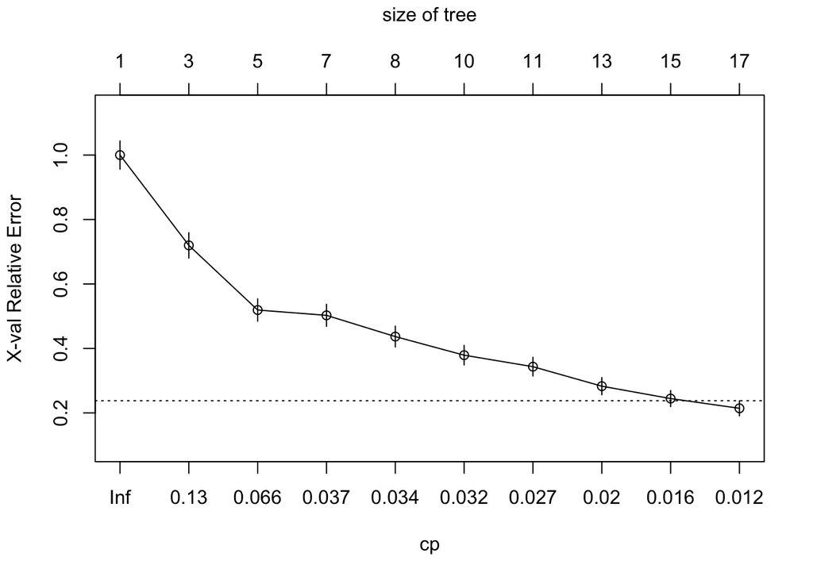

```r
plotcp(tree_model_gini)  # Visualize cp graph
```

```r
# Choose optimal cp value (e.g., lowest cross-validation error)
best_cp_gini <- tree_model_gini$cptable[which.min(tree_model_gini$cptable[, "xerror"]), "CP"]
pruned_tree_gini <- prune(tree_model_gini, cp = best_cp_gini)
print(best_cp_gini)
```

```
## [1] 0.01
```

## Visualize Pruned Tree (Gini)

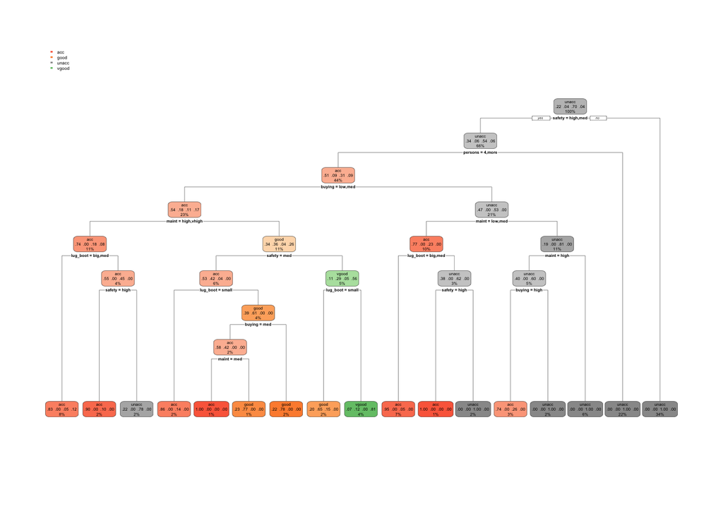

```r
rpart.plot(pruned_tree_gini)
```

## Data Preprocessing for Healthy Data

```r
head(healthydata)   # View the first few rows
```

```
##   visits age phyiscal_health mental_health dental_health employment
## 1      3   2               4             3             3          3
## 2      2   2               4             2             3          3
## 3      3   2               3             2             3          3
## 4      1   2               3             2             3          3
## 5      3   2               3             3             3          3
## 6      2   2               3             2             4          3
##   stress_prevents_sleeping medication_prevents_sleeping pain_prevents_sleeping
## 1                        0                            0                      0
## 2                        1                            0                      0
## 3                        0                            0                      0
## 4                        0                            0                      0
## 5                        1                            0                      0
## 6                        0                            0                      0
##   bathroom_prevents_sleeping unknown_prevents_sleeping trouble_sleeping
## 1                          0                         1                2
## 2                          1                         0                3
## 3                          0                         1                3
## 4                          1                         0                3
## 5                          0                         0                2
## 6                          1                         0                3
##   prescription_sleep_meds race gender
## 1                       3    1      2
## 2                       3    1      1
## 3                       3    4      1
## 4                       3    4      2
## 5                       3    1      2
## 6                       3    1      1
```

```r
str(healthydata)    # Check the structure (columns, types)
```

```
## 'data.frame':    714 obs. of  15 variables:
##  $ visits                      : int  3 2 3 1 3 2 3 2 2 1 ...
##  $ age                         : int  2 2 2 2 2 2 2 2 2 2 ...
##  $ phyiscal_health             : int  4 4 3 3 3 3 4 3 3 2 ...
##  $ mental_health               : int  3 2 2 2 3 2 1 2 1 1 ...
##  $ dental_health               : int  3 3 3 3 3 4 1 6 2 3 ...
##  $ employment                  : int  3 3 3 3 3 3 3 3 3 1 ...
##  $ stress_prevents_sleeping    : int  0 1 0 0 1 0 0 1 0 0 ...
##  $ medication_prevents_sleeping: int  0 0 0 0 0 0 0 0 0 0 ...
##  $ pain_prevents_sleeping      : int  0 0 0 0 0 0 1 0 1 0 ...
##  $ bathroom_prevents_sleeping  : int  0 1 0 1 0 1 1 0 1 0 ...
##  $ unknown_prevents_sleeping   : int  1 0 1 0 0 0 0 0 0 1 ...
##  $ trouble_sleeping            : int  2 3 3 3 2 3 2 3 3 3 ...
##  $ prescription_sleep_meds     : int  3 3 3 3 3 3 1 3 3 3 ...
##  $ race                        : int  1 1 4 4 1 1 1 1 1 1 ...
##  $ gender                      : int  2 1 1 2 2 1 1 1 2 1 ...
```

```r
dim(healthydata)    # Check dimensions (rows, columns)
```

```
## [1] 714  15
```

```r
# Check for missing values
colSums(is.na(healthydata))
```

```
##                       visits                          age
##                            0                            0
##              phyiscal_health                mental_health
##                            0                            0
##                dental_health                   employment
##                            0                            0
##     stress_prevents_sleeping medication_prevents_sleeping
##                            0                            0
##       pain_prevents_sleeping   bathroom_prevents_sleeping
##                            0                            0
##    unknown_prevents_sleeping             trouble_sleeping
##                            0                            0
##      prescription_sleep_meds                         race
##                            0                            0
##                       gender
##                            0
```

```r
# Convert categorical variables to factors
healthydata[] <- lapply(healthydata, as.factor)

# Split into training and test sets
set.seed(123)
trainIndex2 <- createDataPartition(healthydata$visits, p = 0.7, list = FALSE)
trainSet2 <- healthydata[trainIndex2, ]
testSet2 <- healthydata[-trainIndex2, ]
```

## Build Decision Tree (Information Gain)

```r
tree_model_healthy <- rpart(visits ~ ., data = trainSet2, method = "class",
                    parms = list(split = "information"))
ls()
```

```
##  [1] "best_cp"            "best_cp_gini"       "cardata"
##  [4] "healthydata"        "pred_test"          "pred_test_gini"
##  [7] "pred_test_pruned"   "pred_train"         "pred_train_gini"
## [10] "pred_train_pruned"  "pruned_tree"        "pruned_tree_gini"
## [13] "test_error"         "test_error_gini"    "test_error_pruned"
## [16] "testSet"            "testSet2"           "train_error"
## [19] "train_error_gini"   "train_error_pruned" "trainIndex"
## [22] "trainIndex2"        "trainSet"           "trainSet2"
## [25] "tree_model"         "tree_model_gini"    "tree_model_healthy"
```

## Visualize Decision Tree

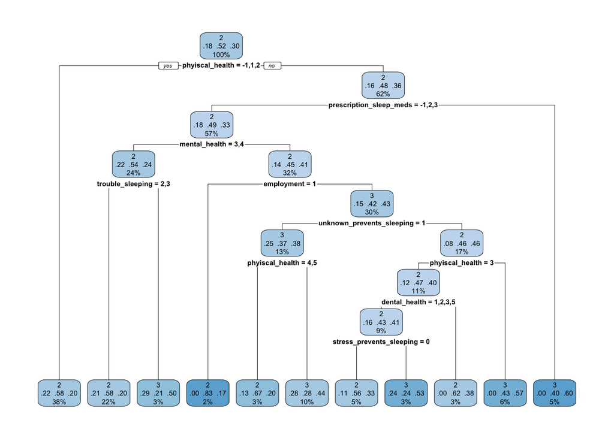

```r
rpart.plot(tree_model_healthy, box.palette = "Blues")
```

## Compute Classification Error

```r
pred_trained_info <- factor(predict(tree_model_healthy, trainSet2, type = "class"),
                          levels = levels(trainSet2$visits))
pred_testing_info <- factor(predict(tree_model_healthy, testSet2, type = "class"),
                         levels = levels(testSet2$visits))

trained_error_info <- mean(pred_trained_info != trainSet2$visits)
testing_error_info <- mean(pred_testing_info != testSet2$visits)

cat("Training Error (Info Gain):", trained_error_info, "\n")
```

```
## Training Error (Info Gain): 0.4271457
```

```r
cat("Test Error (Info Gain):", testing_error_info, "\n")
```

```
## Test Error (Info Gain): 0.4882629
```

## Prune the Tree

```r
printcp(tree_model_healthy) # Display complexity parameter table
```

```
##
## Classification tree:
## rpart(formula = visits ~ ., data = trainSet2, method = "class",
##     parms = list(split = "information"))
##
## Variables actually used in tree construction:
## [1] dental_health             employment
## [3] mental_health             phyiscal_health
## [5] prescription_sleep_meds   stress_prevents_sleeping
## [7] trouble_sleeping          unknown_prevents_sleeping
##
## Root node error: 240/501 = 0.47904
##
## n= 501
##
##         CP nsplit rel error xerror     xstd
## 1 0.010417      0   1.00000 1.0000 0.046590
## 2 0.010000     10   0.89167 1.0167 0.046616
```

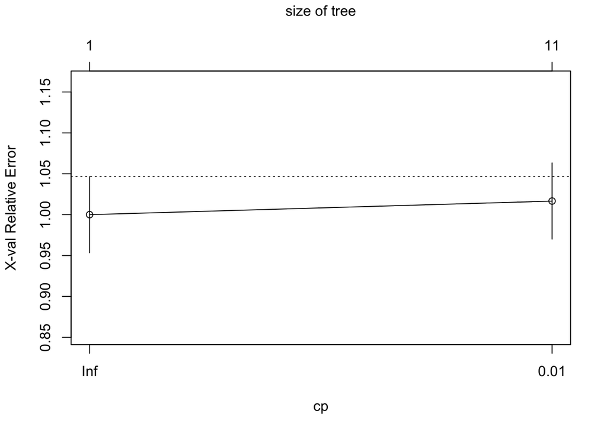

```r
plotcp(tree_model_healthy)  # Visualize cp graph
```

```r
# Choose optimal cp value (e.g., lowest cross-validation error)
best_cp_info <- tree_model_healthy$cptable[which.min(tree_model_healthy$cptable[, "xerror"]), "CP"]
pruned_tree_healthy <- prune(tree_model_healthy, cp = best_cp_info)
```

## Visualize Pruned Tree

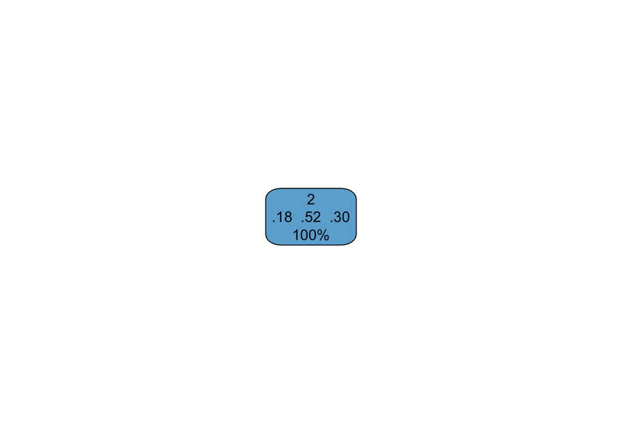

```r
rpart.plot(pruned_tree_healthy, box.palette = "Blues")
```

## Compute Classification Error After Pruning

```r
pred_train_pruned_info <- predict(pruned_tree_healthy, trainSet2, type = "class")
pred_test_pruned_info <- predict(pruned_tree_healthy, testSet2, type = "class")

train_error_pruned_info <- mean(pred_train_pruned_info != trainSet2$visits)
test_error_pruned_info <- mean(pred_test_pruned_info != testSet2$visits)

cat("Pruned Training Error (Info Gain):", train_error_pruned_info, "\n")
```

```
## Pruned Training Error (Info Gain): 0.4790419
```

```r
cat("Pruned Test Error (Info Gain):", test_error_pruned_info, "\n")
```

```
## Pruned Test Error (Info Gain): 0.4788732
```

## Conclusion

The pruned decision tree collapsed to just a root node, it may suggest: The Predictive Power of Features is Weak The features may not have strong relationships with the target variable. Check the variable importance to see if any features are contributing to the model.

```r
varImp(tree_model_healthy)
```

```
##                                 Overall
## bathroom_prevents_sleeping    4.6358921
## dental_health                 7.6223124
## employment                   23.5811245
## medication_prevents_sleeping 20.1905494
## mental_health                 9.4326800
## pain_prevents_sleeping        0.8204166
## phyiscal_health              21.2029526
## prescription_sleep_meds      14.3660960
## race                         19.0772354
## stress_prevents_sleeping      6.2339794
## trouble_sleeping             15.5063571
## unknown_prevents_sleeping     7.7992440
## age                           0.0000000
## gender                        0.0000000
```

Age and Gender had no impact.

Possible Next steps: Feature Selection: I might consider dropping age and gender since they had no effect.

Further Analysis: Investigate why pain_prevents_sleeping had such a low score—does the dataset properly capture pain-related sleep disturbances?

Try a Different Model: Another model like Random Forest might yield better results.